# Security and Risk

[video not shown]

## 问题描述

[figure not shown]

**输入:** 一系列用户的定位信息，用户的好友关系，以及从未分享位置的用户(知道他的好友关系)

**输出:** 预测从未分享位置的用户可能去过的地方

## 导入库函数

```python
import numpy as np
import pandas as pd
import matplotlib.pyplot as plt
```

## 读取数据

https://snap.stanford.edu/data/loc-Gowalla.html

```python
# !wget https://wuhanshare-1252843818.cos.ap-guangzhou.myqcloud.com/app/loc-gowalla_edges.txt.gz
# !wget https://wuhanshare-1252843818.cos.ap-guangzhou.myqcloud.com/app/loc-gowalla_totalCheckins.txt.gz
```

```python
# !gunzip loc-gowalla_totalCheckins.txt.gz
# !gunzip loc-gowalla_edges.txt.gz
```

```python
!ls *.txt
```

```
'ls' 不是内部或外部命令，也不是可运行的程序
或批处理文件。
```

**读取朋友关系数据**

```python
friendship = pd.read_csv("loc-gowalla_edges.txt", header=None, delimiter="\t", names=["user_id", "friend_id"], nrows=10000)
```

```python
friendship.tail()
```

|  | user_id | friend_id |
| --- | --- | --- |
| 9995 | 65 | 6682 |
| 9996 | 65 | 6683 |
| 9997 | 65 | 6684 |
| 9998 | 65 | 6685 |
| 9999 | 65 | 6696 |

**读取 Check-in 数据**

```python
checkin = pd.read_csv("loc-gowalla_totalCheckins.txt", header=None, delimiter="\t", names=["user_id", "time","lat", "lon", "loc_id"], nrows=13000)
```

```python
checkin.tail()
```

|  | user_id | time | lat | lon | loc_id |
| --- | --- | --- | --- | --- | --- |
| 12995 | 66 | 2010-09-14T03:39:46Z | 30.266891 | -97.745686 | 9223 |
| 12996 | 66 | 2010-09-14T00:15:39Z | 30.270211 | -97.749713 | 15478 |
| 12997 | 66 | 2010-09-13T23:52:04Z | 30.269103 | -97.749395 | 420315 |
| 12998 | 66 | 2010-09-13T16:41:54Z | 30.269103 | -97.749395 | 420315 |
| 12999 | 66 | 2010-09-13T01:40:01Z | 30.270734 | -97.753703 | 9241 |

## 数据预处理

### Friendship 分析

```python
friendship_users = friendship.groupby("user_id").count()
print("Mean friends: \t", str(float(friendship_users.mean())))
print("Max friends: \t", str(int(friendship_users.max())))
print("Min friends: \t", str(min(friendship_users.min())))
```

```
Mean friends: 	 151.5151515151515
Max friends: 	 1539
Min friends: 	 5
```

```python
def is_friend(user1, user2):
    return friendship[ (friendship["user_id"] == user1) & (friendship["friend_id"] == user2) ] is not None
```

```python
is_friend(1, 999)
```

```
True
```

### Check-in 地理位置分析

```python
checkin_users = checkin[["user_id","loc_id"]].groupby("user_id").count()
friendship_users = friendship[["user_id","friend_id"]].groupby("user_id").count()
```

```python
print("Checkin users: \t" + str(len(checkin_users)))
print("Total users: \t" + str(len(friendship_users)))
print("Checkin rate: \t" + str(len(checkin_users)/len(friendship_users)))
```

```
Checkin users: 	61
Total users: 	66
Checkin rate: 	0.9242424242424242
```

```python
print("Mean checkin: \t", str(float(checkin_users.mean())))
print("Max checkin: \t", str(int(checkin_users.max())))
print("Min checkin: \t", str(int(checkin_users.min())))
```

```
Mean checkin: 	 213.11475409836066
Max checkin: 	 2100
Min checkin: 	 2
```

**找出没有 check-in 的用户**

```python
checkin_users_index = list(checkin_users.index)
friendship_users_index = list(friendship_users.index)
```

```python
for user in friendship_users_index:
    if user not in checkin_users_index:
        print(user)
```

```
3
6
33
38
45
46
```

**找出没有记录朋友关系的用户**

```python
for user in checkin_users_index:
    if user not in friendship_users_index:
        print(user)
```

```
66
```

### Check-in 坐标分析

https://geoffboeing.com/2014/08/clustering-to-reduce-spatial-data-set-size/

```python
checkin_locs = np.unique(checkin['loc_id'])
print("总坐标数:", str(len(checkin_locs)) )
```

```
总坐标数: 7979
```

**找出人多的地点**

```python
# !pip install geopy shapely
```

```python
from sklearn.cluster import DBSCAN
from geopy.distance import great_circle
from shapely.geometry import MultiPoint
```

```python
coords = checkin[checkin.columns[2:4]].to_numpy()
kms_per_radian = 6371.0088
epsilon = 0.3 / kms_per_radian
```

```python
db = DBSCAN(eps=epsilon, min_samples=20, algorithm='ball_tree', metric='haversine').fit(np.radians(coords))
```

```python
cluster_labels = db.labels_
num_clusters = len(set(cluster_labels))
clusters = pd.Series([coords[cluster_labels == n] for n in range(num_clusters)])

print('Number of clusters: {}'.format(num_clusters))
```

```
Number of clusters: 79
```

```python
def get_centermost_point(cluster):
    if len(cluster) != 0:
        centroid = (MultiPoint(cluster).centroid.x, MultiPoint(cluster).centroid.y)
        centermost_point = min(cluster, key = lambda point: great_circle(point, centroid).m)
        return tuple(centermost_point)
    else:
        return None
```

```python
centermost_points = clusters.map(get_centermost_point)
centermost_points = list(filter(None, centermost_points))
```

```python
centermost_points
```

```
[(30.2688327848, -97.7462379451),
 (30.255337126999997, -97.7626669407),
 (40.64452575, -73.7811048333),
 (40.7310740772, -73.9918962051),
 (40.741298779699996, -74.0055263042),
 (40.7612729, -73.9740371667),
 (30.2493640765, -97.74947047229999),
 (30.201557329699998, -97.6671266556),
 (37.616356064899996, -122.3861503601),
 (37.4221823969, -122.2042644975),
 (37.416124833299996, -122.1491576),
 (37.7854359476, -122.4039494991),
 (30.2643385667, -97.73053245),
 (37.79571789, -122.39476442),
 (34.0443563333, -118.2661700167),
 (34.0172734606, -118.44750881200001),
 (34.03002165, -118.4676396),
 (34.0517349509, -118.2570827007),
 (37.7113487167, -122.2123540667),
 (37.8266990556, -122.4223682284),
 (37.7731587, -122.2348441333),
 (34.19637725, -118.3519364),
 (34.0985153267, -118.28767960799999),
 (34.0479105787, -118.2393490464),
 (34.013867533, -118.49384916700001),
 (37.8360118333, -122.26292648329999),
 (37.8574110833, -122.2529757),
 (37.8710589796, -122.2631483616),
 (37.8504905582, -122.2525033523),
 (33.955762982399996, -118.3971369267),
 (37.699994029, -122.483419828),
 (37.76041745, -122.50905990000001),
 (37.7785348, -122.39298265),
 (30.2955357104, -97.7416491508),
 (37.442601, -122.165838),
 (38.911478883, -94.76443501700001),
 (42.3583963667, -71.05930075),
 (37.42594087, -122.14642876),
 (32.844584573, -96.8498468399),
 (40.7510526892, -73.9947223663),
```

[output cut: 23 more lines]

```
 (33.1260779667, -96.79282265),
 (33.1206988175, -96.80463964719999),
 (37.7663795167, -122.4187049667),
 (42.3744375443, -71.1182892323),
 (37.5384700167, -122.3635768833),
 (37.5314503676, -122.3589205742),
 (37.6601103089, -122.4774707581),
 (37.6826011167, -122.4873168833),
 (37.6956629167, -122.49137935),
 (37.728270067, -122.47687107799999),
 (37.7773331402, -122.4616418474),
 (37.7831089333, -122.4628400667),
 (37.75402355, -122.4186912),
 (37.7355066333, -122.5030088833),
 (38.9687853138, -95.2350175381)]
```

```python
lats, lons = zip(*centermost_points)
rep_points = pd.DataFrame({'lon':lons, 'lat':lats})
rs = rep_points.apply(lambda row: checkin[(checkin['lat']==row['lat']) & (checkin['lon']==row['lon'])].iloc[0], axis=1)
```

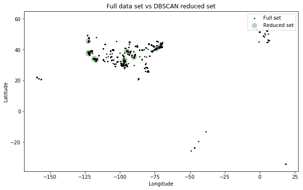

```python
fig, ax = plt.subplots(figsize=[10, 6])

rs_scatter = ax.scatter(rs['lon'], rs['lat'], c='#99cc99', edgecolor='None', alpha=0.7, s=120)
df_scatter = ax.scatter(checkin['lon'], checkin['lat'], c='k', alpha=0.9, s=3)
ax.set_title('Full data set vs DBSCAN reduced set')
ax.set_xlabel('Longitude')
ax.set_ylabel('Latitude')
ax.legend([df_scatter, rs_scatter], ['Full set', 'Reduced set'], loc='upper right')

plt.show()
```

```python
# !pip install plotly
```

```python
import plotly.graph_objects as go
```

```python
fig = go.Figure(data=go.Scattergeo(
        lon = rs['lon'],
        lat = rs['lat'],
        mode = 'markers',
        ))
fig.update_layout(
#         title = 'Most trafficked US airports<br>(Hover for airport names)',
        geo_scope='usa',
    )
fig.show()
```

[interactive chart not shown]

## 参考文献

**Dataset**  
[1] Cho E, Myers S A, Leskovec J. Friendship and mobility: user movement in location-based social networks. Proceedings of the 17th ACM SIGKDD international conference on Knowledge discovery and data mining. ACM, 2011: 1082-1090.

**Review**  
[2] Bao J, Zheng Y, Wilkie D, et al. Recommendations in location-based social networks: a survey. GeoInformatica, 2015, 19(3): 525-565.  
[3] Hu X, Chu T H S, Leung V C M, et al. A survey on mobile social networks: Applications, platforms, system architectures, and future research directions. IEEE Communications Surveys & Tutorials, 2015, 17(3): 1557-1581.

**Research**  
[4] Bilogrevic I, Huguenin K, Agir B, et al. A machine-learning based approach to privacy-aware information-sharing in mobile social networks. Pervasive and Mobile Computing, 2016, 25: 125-142.  
[5] Hongjian Wang, Zhenhui Li, Wang-Chien Lee, PGT: Measuring Mobility Relationship Using Personal, Global and Temporal Factors, Proc. of 2014 IEEE Int. Conf. on Data Mining (ICDM'14), Shenzhen, China, Dec. 2014.

https://faculty.ist.psu.edu/jessieli/Publications/ICDM14-HWang.pdf  
https://faculty.ist.psu.edu/jessieli/Publications/ICDM14-PGT-slides.pdf